# Semana 04 - Code sessions.Rmd

Caja de herramientas: Regresion, eleccion binaria, y propensity score

Carlos Daboín

May, 2022

# Cargando librerias

```r
library(tidyverse) # Hablamos de esto en clase 1. Ya saben para que es.
library(haven)     # Para leer archivos en formato dta. (el formato preferido de Stata)
library(huxtable)  # Para tablas de regresion en HTML (ver otras opciones para distintos formatos i.e. stargazzer para LaTeX
library(patchwork) # juntar graficos lado a lado
library(wooldridge) # datos para estudios
library(estimatr)
```

# Motivacion: LaLonde (1986)

Tomaremos prestado un ejemplo del libro de Econometria de Wooldridge (la data esta disponible en el paquete wooldridge).

LaLonde (1986) estudia el efecto de programas de un amplio programa de entrenamiento laboral en los ingresos de los asistentes 2 años despues (periodo 1975-1978).

Una parte de su estudio analiza datos donde las personas fueron asignadas a programas de entrenamiento experimentalmente. Esos datos se encuentran en el data.frame *jtrain2*.

Otra parte del estudio analiza datos donde las personas podian escoger si asistir o no de forma voluntaria. Estos datos se encuentran en el data.frame *jtrain3*.

Nuestra meta es discutir las diferencias entre los resultados experimentales y los observacionales, y ver como solventarlas.

```r
#EXPERIMENT (experimental)
data(jtrain2)
jtrain2 %>% group_by(train) %>% summarize(wage = mean(re78))
```

| train | wage |
| --- | --- |
| 0 | 4.55 |
| 1 | 6.35 |

```r
#BY CHOICE (non experimental/observacional)
data(jtrain3)
jtrain3 %>% group_by(train) %>% summarize(wage = mean(re78))
```

| train | wage |
| --- | --- |
| 0 | 21.6 |
| 1 | 6.35 |

## Que puede estar pasando acá?

Veamos las “puertas traseras” que enfrentamos al analizar *jtrain3*.

La gente que necesita programas de entrenamiento tiende a tener menores salarios por diversas razones. A se les ocurre alguna?

Tambien hay otros elementos no observables (U) que afectan directamente las chances de recibir entrenamiento y las chances de tener menores salarios, sin tener nada que ver con necesitar o no programas de entrenamiento. Se les ocurre alguno? (pista: Hablamos de eso en la clase pasada).

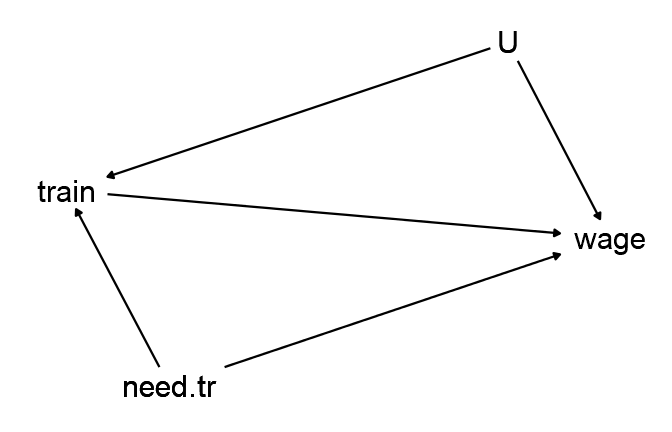

NoteDiagrama causal LaLonde (1986), from Nick Hunktington-Klein CausalitySlides Repo

## Manzanas con peras

Si nos fijamos, los dos grupos de personas tenian ingresos muy distintos antes de recibir el tratamiento

```r
select(jtrain2,re75,re78) %>%  summary()
```

```
##       re75             re78
##  Min.   : 0.000   Min.   : 0.000
##  1st Qu.: 0.000   1st Qu.: 0.000
##  Median : 0.000   Median : 3.702
##  Mean   : 1.377   Mean   : 5.301
##  3rd Qu.: 1.221   3rd Qu.: 8.125
##  Max.   :25.142   Max.   :60.308
```

```r
select(jtrain3,re75,re78) %>%  summary()
```

```
##       re75              re78
##  Min.   :  0.000   Min.   :  0.000
##  1st Qu.:  7.605   1st Qu.:  9.243
##  Median : 17.008   Median : 19.432
##  Mean   : 17.851   Mean   : 20.502
##  3rd Qu.: 25.584   3rd Qu.: 28.816
##  Max.   :156.653   Max.   :121.174
```

## Controlando comparaciones manualmente

Ya que la muestra de los sujetos voluntarios tiene salarios mucho mas altos pre-eleccion del tratamiento, limitemos el analisis a los individuos de menores ingresos en las dos muestras. Usemos un limtie de salario maximo arbitrario por ahora (mas adelante veremos maneras mas consistentes de lograr esto).

Ahora los estimados se asemejan un poco mas:

```r
jtrain2 %>%
  filter(re75<2) %>%
  group_by(train) %>%
  summarize(wage = mean(re78))
```

| train | wage |
| --- | --- |
| 0 | 4.43 |
| 1 | 6.32 |

```r
jtrain3 %>%
  filter(re75<2.) %>%
  group_by(train) %>%
  summarize(wage = mean(re78))
```

| train | wage |
| --- | --- |
| 0 | 5.61 |
| 1 | 6.32 |

Si, nos acercamos un poco pero mo interpretemos estos estimados seriamente (por fa):

1. Usamos un metodo sumamente arbitrario.
2. Aun queda abierta la “puerta” **train <- U -> wage** (raza, edad, genero, etc).

## Controlando comparaciones con la regresion

La clase pasada hablamos como la regresion es un metodo de estimacion lineal que nos sirve para estimar esperanzas condicionales.

- El promedio del salario condicional al tratamiento es precisamente eso: una esperanza condicional.
- Lo lindo es que no tenemos que parar ahi. Con poco esfuerzo podemos obtener el promedio del salario condicional al tratamiento, al salario, a la edad, a la raza, etc.

```r
# Asi creo las regresiones, el comando lm() no pertenece a ningun paquete, sino que esta en R base
experiment_lm<-lm(re78~ train,, data=jtrain2)
no_control_lm<-lm(re78~ train, data = jtrain3)
wage_control_lm<-lm(re78~ train+re75, data = jtrain3)

huxreg( experiment_lm,no_control_lm,wage_control_lm,
       statistics = c("N. obs." = "nobs",
      "R squared" = "r.squared", "F statistic" = "statistic",
      "P value" = "p.value"))
```

|  | (1) | (2) | (3) |
| --- | --- | --- | --- |
| (Intercept) | 4.555 *** | 21.554 *** | 5.653 *** |
|  | (0.408) | (0.304) | (0.360) |
| train | 1.794 ** | -15.205 *** | -0.582 |
|  | (0.633) | (1.155) | (0.841) |
| re75 |  |  | 0.834 *** |
|  |  |  | (0.015) |
| N. obs. | 445 | 2675 | 2675 |
| R squared | 0.018 | 0.061 | 0.553 |
| F statistic | 8.039 | 173.415 | 1652.018 |
| P value | 0.005 | 0.000 | 0.000 |
| *** p < 0.001; ** p < 0.01; * p < 0.05. |  |  |  |

Fijense que tenemos resultados similares a los anteriores:

## ¿Como obtener estos resultados en R?

### Tu primera opción: `lm()`

- lm() es la funcion para estimar modelos de regresion lineal en R base.
- Especificas las variables dependientes e independientes de la regresion con una formula: `lm(y ~ x)`
- Los elementos anadidos en la formula tienen que contener datos (ser vectores). Hay varias maneras de especificar esto cuando x y y son vectores del mismo data.frame:
1. `lm(y ~ x, data= mis_datos)`
2. `lm("y ~ x", data= mis_datos)`
3. `lm(mis_datos$y ~ mis_datos$x)`
- Las estimaciones $y_i = \beta_0 + \beta_1 x_i + u_i$ incluyen un intercepto (aunque puedes removerlo anadiento in -1 a la formula).

### Necesitas añadir mas variables?

Simplemente añadelas en la formula

`lm(y ~ x1 + x2 + x3, data = mis_datos)` * Estima $y_i = \beta_0 + \beta_1 x_{1i} + \beta_2 x_{2i} + \beta_3 x_{3i} + u_i$ * Es necesario que x1, x2 y x3 sean columnas del data.frame *mis_datos*.

### Necesitas transformar alguna variable?

Es sencillo, transformalas adentro de la formula usando `I()`.

`lm(y ~ x1 + x2 + I(x1^2) + I(x2^2) + I(x1*x2), data = mis_datos)` * Estima $y_i = \beta_0 + \beta_1 x_{1i} + \beta_2 x_{2i} + \beta_3 x_{1i}^2 + \beta_4 x_{2i}^2 + \beta_5 x_{1i} x_{2i} + u_i$

Tambien se puede especificar de otras formas: - `lm(y ~ x1 + x2 + I(x1*x2))` - `lm(y ~ x1 + x2 + x1:x2)` - `lm(y ~ x1*x2)`

**Nota:** Repasa por tu cuenta el capítulo 4 de The Effect “Describing Relationships” para refrescar un poco las nociones detras de estas transformaciones.

### Resultados del `lm()`

Revisemos el output del comando lm para las regresiones del comando aterior:

```r
lm(re78~ train, data=jtrain2)
```

```
##
## Call:
## lm(formula = re78 ~ train, data = jtrain2)
##
## Coefficients:
## (Intercept)        train
##       4.555        1.794
```

Parece poca información ¿cierto? Hagámoslo una vez mas pero guardemoslo en un objeto para revisarlo.

```r
revisa_lm<-lm(re78~ train, data=jtrain2)

# revisa_lm es una clase particular de objeto llamada lm (Linear model)
revisa_lm %>% class()
```

```
## [1] "lm"
```

```r
# Si imprimes los contenidos del objeto salen a relucir varias piezas
revisa_lm %>% names()
```

```
##  [1] "coefficients"  "residuals"     "effects"       "rank"
##  [5] "fitted.values" "assign"        "qr"            "df.residual"
##  [9] "xlevels"       "call"          "terms"         "model"
```

```r
revisa_lm
```

```
##
## Call:
## lm(formula = re78 ~ train, data = jtrain2)
##
## Coefficients:
## (Intercept)        train
##       4.555        1.794
```

#### Podemos presentar resumenes elaborados de `lm()` con `huxreg()` y otras funciones

```r
huxreg(revisa_lm)
```

|  | (1) |
| --- | --- |
| (Intercept) | 4.555 *** |
|  | (0.408) |
| train | 1.794 ** |
|  | (0.633) |
| N | 445 |
| R2 | 0.018 |
| logLik | -1468.790 |
| AIC | 2943.580 |
| *** p < 0.001; ** p < 0.01; * p < 0.05. |  |

#### Podemos poner los datos de `lm()` en formato `tidy’

```r
# instala el paquete estimatr
estimatr::tidy(revisa_lm)
```

| term | estimate | std.error | statistic | p.value |
| --- | --- | --- | --- | --- |
| (Intercept) | 4.55 | 0.408 | 11.2 | 1.15e-25 |
| train | 1.79 | 0.633 | 2.84 | 0.00479 |

#### Podemos extraer predicciones

Hay dos escenarios en los que podemos necesitar las predicciones de un modelo.

- Quieres las predicciones de la data que usaste para modelar (i.e. propensity score)

```r
revisa_lm$fitted.values
```

- Quieres predicciones para nuevos valores de la data

```r
predict(
  object = revisa_lm,
  newdata = mismos_datos_en_venezuela,
  interval = "prediction"
)
```

## Otras regresions

Minimios Cuadrados Ordinarios (MCO) es uno de los muchos metodos disponibles para hacer regresiones.

Hay ocasiones en las que nos interesa estimar probabilidades condicionales, para lo que el método de MCO no es muy bueno: * Imagina que queremos saber la probabilidad de ser inscribirse en un programa de entrenamiento. * Al ser lineal y estimarse sobre variables continuas tiende a predecir valores por fuera del rango (0,1). * Asume que efectos en las puntas son iguales a efectos en el medio (aveces nos interesa mas el efecto en el medio).

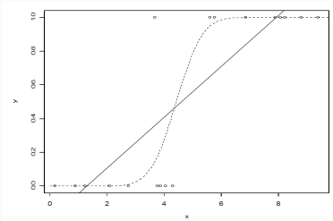

Predicciones de Logit y OLS de variables binarias

En estas ocasiones nos conviene acudir a los modelos logit y probit, los cuales transforman un modelo lineal en una función no lineal (Leanse el apartado en el capítulo 13 the the Effect para mas detalles). Hay muchos detalles interesantes acerca de estos modelos que no cubriremos aca. El mas relevante es que los coeficientes de estos modelos *no* pueden ser interpretados como efectos marginales en la probabilidad.

El modelo logit usa la funcion `glm()` (glm viene de modelos lineales generalizados).

Para estimar la probabilidad de tratamiento en los datos de LaLonde, hacemos lo siguiente:

```r
glm(
  treat ~ age + educ + black + hisp + married,
  family = "binomial",
  data = jtrain3
)
```

# Juntando el arsenal

Usaremos lo aprendido para replicar los resultados presentados en el [Capítulo 5 de Causal Inference the Mixtape, sección 5.3.4](https://mixtape.scunning.com/matching-and-subclassification.html?panelset4=r-code5&panelset5=r-code6&panelset6=r-code7#example-the-nsw-job-training-program).

El ejercicio se basa en el mismo expermento analizado por LaLonde (1986), extendido analíticamente por Deheijia y Wahba (1999).

El estudio de LaLonde (1986) consistió en medir el ATE con datos experimentales (The National Supported Work Demonstration - NSW) y con datos no experimentales (Current Population Survey), y compararlos. Como vimos arriba, los estimados son drásticamente diferentes, lo que llevó a muchos a la conclusión pesimista de que los datos no-experimentales no eran apropiados para la evaluación depolíticas públicas.

Años después, Deheijia y Wahba (1999) añaden el propensity score a la discusión, y prueban su funcionamiento cómo método de diagnóstico y cómo mecanismo de matching para mejorar las estimaciones. Para ello usan los mismos datos no experimentales usados por LaLonde (1986).

## Calculemos de nuevo el efecto del tratamiento en la data experimental

```r
# Creamos una funcion que descarga nuestros datos desde un repositorio la interenet
read_data <- function(df) {
  full_path <- paste("https://raw.github.com/scunning1975/mixtape/master/",
                     df, sep = "")

  # full_path contiene la URL donde esta guardada la data
  # el usuario solo debe especificar el nombre de los datos. Si en el repositorio no existen
  # datos con ese nombre, arrojara un error

  df <- read_dta(full_path)
  return(df)
}

nsw_dw <- read_data("nsw_mixtape.dta")

# Calculo la media de los tratados
mean1 <- nsw_dw %>%
  filter(treat == 1) %>%
  pull(re78) %>%
  mean()

## Creo columna cuyo unico valor es la media de los tratados
nsw_dw$y1 <- mean1 # con dplry pudieramos hacer algo asi: a nsw_dw %>% mutate(y1=mean1)

# Calculo la media de los no tratados
mean0 <- nsw_dw %>%
  filter(treat == 0) %>%
  pull(re78) %>%
  mean()

## Creo columna cuyo unico valor es la media de los no tratados
nsw_dw$y0 <- mean0

ate <- unique(nsw_dw$y1 - nsw_dw$y0)
ate
```

```
## [1] 1794.342
```

```r
## remuevo columnas con los promedios
nsw_dw <- nsw_dw %>%
  filter(treat == 1) %>%
  select(-y1, -y0)
```

## Creando el propensity score para evaluar el problema

```r
# Descargamos unos datos nuevos del repositorio
# Estos son del Current Population Survey, una encuesta de hogares MENSUAL hecha en EEUU.
# la gente del CPS son iguales a los de jtrain3 (No experimentales)
nsw_dw_cpscontrol <- read_data("cps_mixtape.dta") %>%
  # usamos bind_rows para juntar los registros experimentales y no experimentales
  bind_rows(nsw_dw) %>%
  # Creamos variables al cuadrado, interacciones, variables binarias, y mas
  # Sugerencia: Repasen como se interpretan los coeficientes de estas variables en un MCO
  mutate(agesq = age^2,
         agecube = age^3,
         educsq = educ*educ,
         u74 = case_when(re74 == 0 ~ 1, TRUE ~ 0),
         u75 = case_when(re75 == 0 ~ 1, TRUE ~ 0),
         interaction1 = educ*re74,
         re74sq = re74^2,
         re75sq = re75^2,
         interaction2 = u74*hisp)

# estimating using a LOGIT link function
logit_nsw <- glm(treat ~ age + agesq + agecube + educ + educsq +
                   marr + nodegree + black + hisp + re74 + re75 + u74 +
                   u75 + interaction1, family = binomial(link = "logit"),
                 data = nsw_dw_cpscontrol)

## Extraigo las predicciones de probabilidad para cada observacion, que estan guardadas en logit_nsw$fitted.values
nsw_dw_cpscontrol <- nsw_dw_cpscontrol %>%
  mutate(pscore = logit_nsw$fitted.values)

## Calculo el promedio del pscore para tratados y no los no tratados
nsw_dw_cpscontrol %>%
  group_by(treat) %>%
  summarise(pscore=mean(pscore))
```

| treat | pscore |
| --- | --- |
| 0 | 0.00665 |
| 1 | 0.425 |

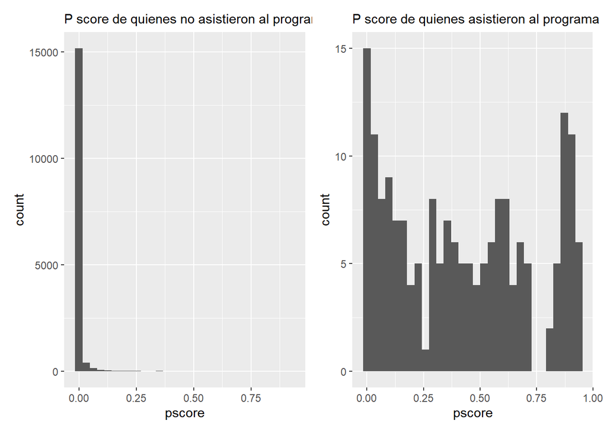

```r
# Hagamos unos graficos de distribucion tipo histograma
# Primera vez que hacemos uno.
p1<-nsw_dw_cpscontrol %>%
  filter(treat == 0) %>%
  ggplot() +
  geom_histogram(aes(x = pscore))+
  labs(subtitle="P score de quienes no asistieron al programa")

p2<-nsw_dw_cpscontrol %>%
  filter(treat == 1) %>%
  ggplot() +
  geom_histogram(aes(x = pscore))+
  labs(subtitle="P score de quienes asistieron al programa")

# juntemos ambos graficos lado a lado
library(patchwork)
p1+p2
```

## Usos del propensity score en la estimación

- **Matching con vecino mas cercano**: Compara el efecto del tratamiento entre dos individuos con el score mas cercano posible.
- **Matching exacto en base a segmentos**: Segmenta la data en diferentes tramos de score de igual longitud que tengan proporciones similares de control y tratamiento.

### Usando el propensity score como peso

El propensity score te ayuda a darle mayor peso a los registros con menos probabilidad de ser tratados, y menor peso a los que tenian mas probabilidad de serlo.

```r
#- Manual with non-normalized weights using all data

nsw_dw_cpscontrol <- nsw_dw_cpscontrol %>%
  mutate(y1 = treat * re78/pscore,
         y0 = (1-treat) * re78/(1-pscore),
         ht = y1 - y0)

nsw_dw_cpscontrol %>%
  pull(ht) %>%
  mean()
```

```
## [1] -11876.79
```

```r
#- Manual with normalized weights
# continuation. Store the number of observations
N <- nrow(nsw_dw_cpscontrol)

# Store the sum of the adjusted treatment
nsw_dw_cpscontrol <- nsw_dw_cpscontrol %>%
  mutate(d1 = treat/pscore,
         d0 = (1-treat)/(1-pscore))

s1 <- sum(nsw_dw_cpscontrol$d1)
s0 <- sum(nsw_dw_cpscontrol$d0)

nsw_dw_cpscontrol <- nsw_dw_cpscontrol %>%
  mutate(y1 = (treat*re78/pscore)/(s1/N),
         y0 = ((1-treat)*re78/(1-pscore))/(s0/N),
         norm = y1 - y0)


nsw_dw_cpscontrol %>%
  pull(norm) %>%
  mean()
```

```
## [1] -7238.14
```

### Cortando la data para que tenga soporte comun (trimming)

```r
#-- trimming propensity score
nsw_dw_cpscontrol <- nsw_dw_cpscontrol %>%
  select(-d1, -d0, -y1, -y0, -ht, -norm) %>%
  filter(!(pscore >= 0.9)) %>%
  filter(!(pscore <= 0.1))

# Storing number of observations in the data. Now they are fewer
N <- nrow(nsw_dw_cpscontrol)

#- Manual with non-normalized weights using trimmed data
nsw_dw_cpscontrol <- nsw_dw_cpscontrol %>%
  mutate(y1 = treat * re78/pscore,
         y0 = (1-treat) * re78/(1-pscore),
         ht = y1 - y0)
nsw_dw_cpscontrol %>%
  pull(ht) %>%
  mean()
```

```
## [1] 2006.365
```

```r
#- Manual with normalized weights with trimmed data
nsw_dw_cpscontrol <- nsw_dw_cpscontrol %>%
  mutate(d1 = treat/pscore,
         d0 = (1-treat)/(1-pscore))

s1 <- sum(nsw_dw_cpscontrol$d1)
s0 <- sum(nsw_dw_cpscontrol$d0)
nsw_dw_cpscontrol <- nsw_dw_cpscontrol %>%
  mutate(y1 = (treat*re78/pscore)/(s1/N),
         y0 = ((1-treat)*re78/(1-pscore))/(s0/N),
         norm = y1 - y0)



nsw_dw_cpscontrol %>%
  pull(norm) %>%
  mean()
```

```
## [1] 1806.73
```

### Nearest Neighbor Matching

```r
library(MatchIt)
library(Zelig)

m_out <- matchit(treat ~ age + agesq + agecube + educ +
                 educsq + marr + nodegree +
                 black + hisp + re74 + re75 + u74 + u75 + interaction1,
                 data = nsw_dw_cpscontrol, method = "nearest",
                 distance = "logit", ratio =5)

m_data <- match.data(m_out)

z_out <- zelig(re78 ~ treat + age + agesq + agecube + educ +
               educsq + marr + nodegree +
               black + hisp + re74 + re75 + u74 + u75 + interaction1,
               model = "ls", data = m_data)
```

```
## How to cite this model in Zelig:
##   R Core Team. 2007.
##   ls: Least Squares Regression for Continuous Dependent Variables
##   in Christine Choirat, Christopher Gandrud, James Honaker, Kosuke Imai, Gary King, and Olivia Lau,
##   "Zelig: Everyone's Statistical Software," https://zeligproject.org/
```

```r
x_out <- setx(z_out, treat = 0)
x1_out <- setx(z_out, treat = 1)

s_out <- sim(z_out, x = x_out, x1 = x1_out)

summary(s_out)
```

```
##
##  sim x :
##  -----
## ev
##       mean       sd      50%     2.5%    97.5%
## 1 4574.392 455.6882 4565.278 3719.219 5513.844
## pv
##          mean       sd      50%      2.5%    97.5%
## [1,] 4779.719 6494.212 4549.656 -8186.532 17725.94
##
##  sim x1 :
##  -----
## ev
##       mean       sd     50%     2.5%    97.5%
## 1 6253.385 629.2927 6249.87 5047.103 7448.388
## pv
##          mean       sd      50%      2.5%    97.5%
## [1,] 6142.716 6610.918 5987.687 -6207.353 19672.61
## fd
##       mean       sd      50%     2.5%    97.5%
## 1 1678.993 799.1843 1683.543 159.0251 3216.693
```

```r
library(cem)
library(MatchIt)
library(Zelig)
library(tidyverse)
library(estimatr)


m_out <- matchit(treat ~ age + agesq + agecube + educ +
                   educsq + marr + nodegree +
                   black + hisp + re74 + re75 +
                   u74 + u75 + interaction1,
                 data = nsw_dw_cpscontrol,
                 method = "cem",
                 distance = "logit")

m_data <- match.data(m_out)

m_ate <- lm_robust(re78 ~ treat,
               data = m_data,
               weights = m_data$weights)
```

## Referencias

- [The effect, Capítulos 6 y 13 - Nick Hungtinton-Klein](https://theeffectbook.net/ch-StatisticalAdjustment.html)
- [Causal Inference, the Mixtape, Capítulo 5 - Scott Cuningham](https://mixtape.scunning.com/matching-and-subclassification.html)
- [CausalSlides Repository - Lesson 6: Back Doors by Nick Hungtinton-Klein](https://nickch-k.github.io/CausalitySlides/)
- [Srping 2019 Econometrics III at the University of Oregon, dictado por Ed Rubin](https://github.com/edrubin/EC525S19)
- Lalonde, Robert. 1986. “Evaluating the Econometric Evaluations of Training Programs with Experimental Data.” American Economic Review 76 (4): 604–20
- Dehejia, Rajeev H., and Sadek Wahba. 1999. “Causal Effects in Nonexperimental Studies: Reevaluating the Evaluation of Training Programs.” Journal of the American Statistical Association 94 (448): 1053–62. ———. 2002. “Propensity Score-Matching Methods for Nonexperimental Causal Studies.” Review of Economics and Statistics 84 (1): 151–61.